# Lab 2: Mine Crafting

Emmalynn Malixi

## Introduction

### Imports

```python
import numpy as np
import matplotlib.pyplot as plt
from scipy.integrate import solve_ivp
import scipy
```

### Constants

```python
G=6.6743*10**-11 #gravitational constant [m**3/kg/s**2]
g0=9.81 #approximation for gravitational acceleration [m/s**2]
Me=5.972*10**24 #mass of earth [kg]
Mm=7.35*10**22 #mass of moon [kg]
Re=6378.1e3 #radius of earth [m]
Rm=1738.1e3 #radius of moon [m]
w=7.272*10**-5 #earth's rotational rate at the equator [rad/s]
```

## Part 1: The Ideal Case

### Question 1.1

```python
#x=vot+0.5at**2, v0=0
x=4*10**3
a=g0
t_ff=np.sqrt(2*x/a)
print(f'Using kinematics, the test mass would reach the bottom of the 4km shaft after {t_ff} seconds, assuming no drag.')
```

```
Using kinematics, the test mass would reach the bottom of the 4km shaft after 28.55686245854129 seconds, assuming no drag.
```

### Question 1.2

```python
#m=gamma
#a=alpha
a=0
g=g0
m=2

def Q1(t,e):

    y,v=e
    dydt=v
    dvdt=-g+a*v**m
    return[dydt,dvdt]
```

### Question 1.3

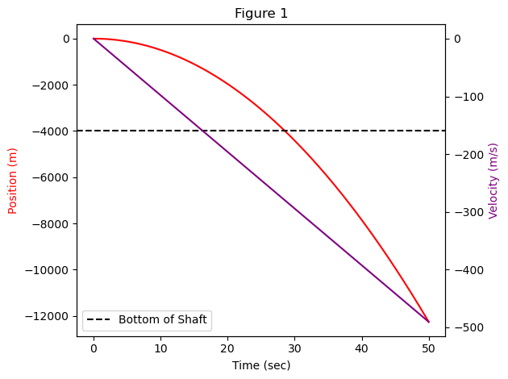

```python
t0,tf=0,50
t_eval=np.linspace(t0,tf,1000)

y0=0 #m
v0=0 #m/s
ic=[y0,v0]

a=0
sol1=solve_ivp(fun=Q1,t_span=(t0,tf),y0=ic,t_eval=t_eval)

position=sol1.y[0]
velocity=sol1.y[1]
t_vals=sol1.t

fig,ax1=plt.subplots()
ax1.plot(t_vals,position,color='red')
ax2=ax1.twinx()
ax2.plot(t_vals,velocity,label='Velocity',color='purple')
ax1.axhline(y=-4000,color='black',ls='--',label='Bottom of Shaft')
ax2.set_title('Figure 1')
ax1.set_xlabel('Time (sec)')
ax1.set_ylabel('Position (m)',color='red')
ax2.set_ylabel('Velocity (m/s)',color='purple')
ax1.legend(loc='lower left')

fig.tight_layout()
```

Figure 1: This figure shows the position and velocity of a test mass falling down a 4km shaft, hitting the bottom at the dotted black line.

### Question 1.4

Time calculation with events detection capability of solve_ivp:

```python
y_stop=-4000 #m
def eventstop(t,e):
    y,v=e
    return y-y_stop

eventstop.terminal=True
sol2=solve_ivp(fun=Q1,t_span=(t0,tf),y0=ic,t_eval=t_eval,events=eventstop)
t_stop=sol2.t_events[0][0]
print(f'Python precision: {t_stop} seconds')
print(f'Rounded:{t_stop:.3g} seconds')
```

```
Python precision: 28.556862458541293 seconds
Rounded:28.6 seconds
```

```python
print(f'The analytic calculation gave a result of {t_ff} seconds, whereas the solve_ivp gave a result of {t_stop} seconds.\n\nTo .1 of a second, both round to 28.6 seconds. Therefore, solving the problem analytically and with the solve_ivp yields the same result.')
```

```
The analytic calculation gave a result of 28.55686245854129 seconds, whereas the solve_ivp gave a result of 28.556862458541293 seconds.

To .1 of a second, both round to 28.6 seconds. Therefore, solving the problem analytically and with the solve_ivp yields the same result.
```

## Part 2: Including Drag and a Variable g

### Question 2.1

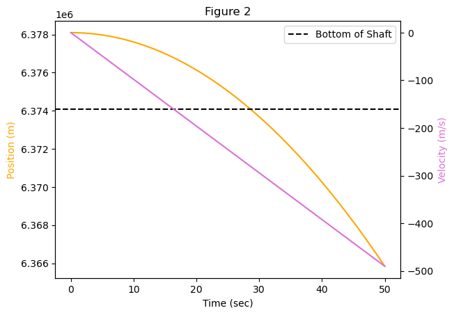

```python
def g(y):
    gy=g0*(y/Re)
    return gy
a=0
m=2

def Q2(t,l):
    y,v=l
    dydt=v
    dvdt=-g(y)+a*v**m
    return[dydt,dvdt]

t0,tf=0,50
t_eval=np.linspace(t0,tf,1000)

y0=Re #m
v0=0 #m/s
ic=[y0,v0]


sol2=solve_ivp(fun=Q2,t_span=(t0,tf),y0=ic,t_eval=t_eval)

position=sol2.y[0]
velocity=sol2.y[1]
t_vals=sol2.t

fig,ax1=plt.subplots()
ax1.plot(t_vals,position,color='orange')
ax2=ax1.twinx()
ax2.plot(t_vals,velocity,label='Velocity',color='orchid')
ax1.axhline(y=Re-4000,color='black',ls='--',label='Bottom of Shaft')
ax2.set_title('Figure 2')
ax1.set_xlabel('Time (sec)')
ax1.set_ylabel('Position (m)',color='orange')
ax2.set_ylabel('Velocity (m/s)',color='orchid')
ax1.legend()
```

Figure 2: This graph portrays the change in position and velocity over time, as well as the impact on the bottom of the shaft along the black line.

### Question 2.2

```python
y_stop=Re-4000
def eventstop(t,l):
    y,v=l
    return y-y_stop

sol=solve_ivp(fun=Q2,t_span=(t0,tf),y0=ic,t_eval=t_eval,events=eventstop)
t_stop2=sol.t_events[0][0]
t_difference=t_stop2-t_stop
print(f'Using a height dependent g yields a fall time of {t_stop2} seconds verses the non heightdependent result of {t_stop} seconds. This is a difference of {t_difference}. \n\nThis small of a difference makes sense since it is only a four kilometer drop, which is minimal compared to the raidus of Earth. The ratio between the mineshaft and the Earth is quite small, and indicates that using a heigh dependent formula does not signifigantly differ in product from the ideal.')
```

```
Using a height dependent g yields a fall time of 28.55835519647798 seconds verses the non heightdependent result of 28.556862458541293 seconds. This is a difference of 0.0014927379366866944.

This small of a difference makes sense since it is only a four kilometer drop, which is minimal compared to the raidus of Earth. The ratio between the mineshaft and the Earth is quite small, and indicates that using a heigh dependent formula does not signifigantly differ in product from the ideal.
```

### Question 2.3

```
The average g between at the bottom and the top is 9.806923848795096 m/s^2
Calibrating α gives you 0.003922769539518038
```

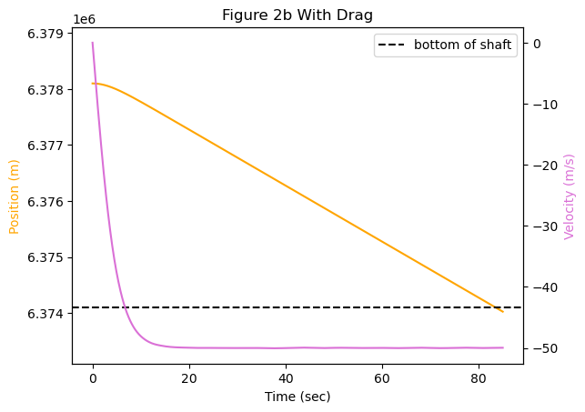

```python
#g_3 is equal to the average between g at the bottom and at the top
g2_3=(g0+g(Re-4000))/2
print(f'The average g between at the bottom and the top is {g2_3} m/s^2')

m=2
v2_3=50 #m/s
alph=g2_3/(v2_3**m)
print(f'Calibrating \u03B1 gives you {alph}')

a=alph

t0,tf=0,85
t_eval=np.linspace(t0,tf,1000)

y0=Re #m
v0=0 #m/s
ic=[y0,v0]

eventstop.terminal=False
sol2=solve_ivp(fun=Q2,t_span=(t0,tf),y0=ic,t_eval=t_eval)

position=sol2.y[0]
velocity=sol2.y[1]
t_val2=sol2.t

fig,ax1=plt.subplots()
ax1.plot(t_val2,position,color='orange')
ax1.set_ylim(Re-5000,Re+1000)
ax2=ax1.twinx()
ax2.plot(t_val2,velocity,label='Velocity',color='orchid')
ax1.axhline(y=Re-4000,color='black',ls='--',label='bottom of shaft')
ax2.set_title('Figure 2b With Drag')
ax1.set_xlabel('Time (sec)')
ax1.set_ylabel('Position (m)',color='orange')
ax2.set_ylabel('Velocity (m/s)',color='orchid')
ax1.legend()
```

Figure 2b With Drag: This graph indicates the position and velocity of the object over time, as well as the impact wth the bottom of the shaft at the dotted black line.

```python
y_stop=Re-4000
def eventstop(t,l):
    y,v=l
    return y-y_stop

eventstop.terminal=True
sol3=solve_ivp(fun=Q2,t_span=(t0,tf),y0=ic,t_eval=t_eval,events=eventstop)
t_stop3=sol3.t_events[0][0]
print(f'The time that the object hits the bottom of the shaft when we take into account the variable g and drag is {t_stop3} seconds.')
```

```
The time that the object hits the bottom of the shaft when we take into account the variable g and drag is 83.53090628365672 seconds.
```

Incorporating drag caused the velocity to rapidly reach terminal velocity and remain there, therefore causing the position to change more slowly. This means that the bottom of the shaft was reached later when a drag affect was considered.

## Part 3: The Coriolis Force

### Question 3.1

```python
mo=1 #kg of test object
#F=ma
#a=d2y/dt
def Q3(t,r3_1):
    x,y,v_x,v_y=r3_1
    dxdt=v_x
    dydt=v_y

    v_y=dydt
    v_x=dxdt
    Fcx=2*mo*w*v_y
    Fcy=-2*mo*w*v_x
#F=ma, so a=F/m
    dv_ydt=-g(y)+a*v_y**m+Fcy/mo
    dv_xdt=Fcx/mo
    return dxdt,dydt,dv_xdt,dv_ydt
```

### Question 3.2

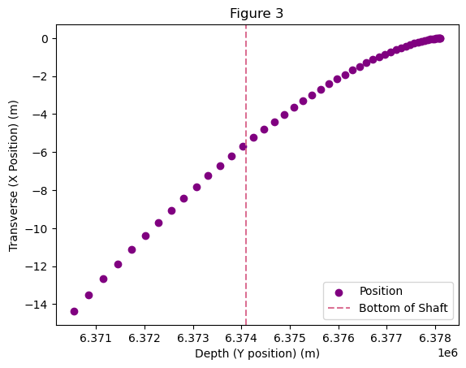

```python
a=0

t0,tf=0,40
t_eval=np.linspace(t0,tf,1000)

x0=0 #m
y0=Re #m
v_y0=0 #m/s
v_x0=0 #m/s
ic=[x0,y0,v_x0,v_y0]

eventstop.terminal=False
sol3=solve_ivp(fun=Q3,t_span=(t0,tf),y0=ic,t_eval=t_eval)
#print(sol3)

x3=sol3.y[0]
y3=sol3.y[1]
v_x3=sol3.y[2]
v_y3=sol3.y[3]
t_vals=sol3.t

fig,ax3=plt.subplots()
ax3.scatter(y3[::20],x3[::20],label='Position',color='purple')
ax3.axvline(x=Re-4000,ls='--',color='palevioletred',label='Bottom of Shaft')
ax3.set_title('Figure 3')
ax3.set_xlabel('Depth (Y position) (m)')
ax3.set_ylabel('Transverse (X Position) (m)')
ax3.legend(loc='lower right')
```

Figure 3: The graph represents the position of the object in transverse and depth as it falls down the shaft, and where it will reach the bottom.